# Submitted data error checks

# 0. Instructions for submitters

Submitters should use this file to check for problems with submitted data. Each of these html files contains a summary of the data from a single submitted spreadsheet file. The html name is based on the name of the submitted file. Use the details below to check:

- Institute abbreviation, submitter and contributor names
- The plot location(s), using the map zoom and pan features if needed
- For problems in the first sections; “OK” means there are no problems in a particular section, “warning” is something that should be checked (but might be OK), “error” is a problem that needs to be addressed
- For numeric values outside the expected range in the “Value checks” section
- Variables with missing values–are there any missing that you thought you included?
- Plots of flux, cumulative emission over time, and final cumulative emission for strange patterns, unexpectedly high or low values
- Plots of weather data for appropriate differences between plots and expected diurnal or other patterns
- Plots of manure and application data for correct values

Finally, the numeric summary at the end might provide details that can help in pinpointing problems, but typically does not need to be checked.

# 1. Submitter

| inst.abbrev | submitter | version | date |
| --- | --- | --- | --- |
| AU | Jesper Nørlem Kamp | 1 | 2021-09-21 |

# 2. Contributors

| contributor | institute |
| --- | --- |
| Kamp, Jesper Nørlem | Aarhus University |
| Häni, Christoph | Bern University of Applied Sciences |
| Nyord, Tavs | Aarhus University |
| Feilberg, Anders | Aarhus University |
| Sørensen, Lise Lotte | Aarhus University |

# 3. File and directory names

```
## [1] "../../data-submitted/03/AU"
```

```
## [1] "../../data-submitted/03/AU/ALFAM2_JNK_2019_Aug_5_5_b.xlsx"
```

# 4. Location

[interactive chart not shown]

# 5.Keys and codes

## Codes in Treatments sheet

```
## OK
```

```
## OK
```

## Codes in Plots sheet

```
## OK
```

```
## OK
```

## Codes in Emission sheet

```
## OK
```

```
## OK
```

## Code merge check (matching project, experiment, field, plot, treatment)

```
## OK
```

```
## OK
```

```
## OK
```

```
## OK
```

```
## OK
```

# 6. Publication info

## Check for missing codes

```
## OK
```

```
## OK
```

## Complete citations given

```
## OK
```

```
## OK
```

# 7. Emission sheet

## Duplicated intervals

```
## OK
```

## Missing incorporation time

```
## OK
```

## Delay after application

| row.in.file.int | app.start | t.start | bta | ct | cta |
| --- | --- | --- | --- | --- | --- |
| 971 | 2019-08-14 06:00:00 | 2019-08-14 17:30:00 | 11.5 | 0.5 | 12.0 |
| 972 | 2019-08-14 06:00:00 | 2019-08-14 18:00:00 | 12.0 | 1.0 | 12.5 |
| 973 | 2019-08-14 06:00:00 | 2019-08-14 18:30:00 | 12.5 | 1.5 | 13.0 |
| 974 | 2019-08-14 06:00:00 | 2019-08-14 19:00:00 | 13.0 | 2.0 | 13.5 |
| 975 | 2019-08-14 06:00:00 | 2019-08-14 19:30:00 | 13.5 | 2.5 | 14.0 |
| 976 | 2019-08-14 06:00:00 | 2019-08-14 20:00:00 | 14.0 | 3.0 | 14.5 |
| 977 | 2019-08-14 06:00:00 | 2019-08-14 20:30:00 | 14.5 | 3.5 | 15.0 |
| 978 | 2019-08-14 06:00:00 | 2019-08-14 21:00:00 | 15.0 | 4.0 | 15.5 |
| 979 | 2019-08-14 06:00:00 | 2019-08-14 21:30:00 | 15.5 | 4.5 | 16.0 |
| 980 | 2019-08-14 06:00:00 | 2019-08-14 22:00:00 | 16.0 | 5.0 | 16.5 |

## Missing or double interval number

```
## OK
## OK
## OK
## OK
```

## Missing time between intervals

```
## OK
## OK
## OK
## OK
```

## Measurement method and units

Measurement technique:

| Method | Frequency |
| --- | --- |
| AGM | 321 |
| bLS | 963 |

Measurement technique classification:

| Classification | Frequency |
| --- | --- |
| micro met | 1284 |

Emission units and conversion factors.

| Original unit | Conversion factor applied | Final unit |
| --- | --- | --- |
| µg NH3/m2/s | 0.0296079 | kg N/ha-hr |

# 7. Value checks

Check to see if submitted values are within a reasonable range.

## Weather

```
## wind : OK
## rain.rate : OK
## air.temp : OK
## soil.temp : OK
## soil.temp.surf : OK
## air.temp.z : OK
## wind.z : OK
```

## Manure and application

```
## man.stor : No values to check.
## man.dm : OK
## man.vs : No values to check.
## man.tkn : OK
## man.tan : OK
## man.tic : No values to check.
## man.ua : No values to check.
## man.vfa : No values to check.
## man.ph : OK
## app.rate : OK
## crop.z : OK
```

## Emission

```
## j.NH3 : OK
## e.int : OK
## e.rel : OK
```

# 8. Missing values

Check for missing values.

## All variables

```
## Some values missing:
## Table below has number of missing observations by variable:
##  meas.tech.det           clay           silt           sand             oc
##            321           1284           1284           1284           1284
##     soil.water   soil.water.v     soil.moist        soil.ph      soil.dens
##           1284           1284           1284           1284           1284
## man.source.det        man.bed       man.trt2       man.stor         man.vs
##           1284           1284           1284           1284           1284
##        man.tic         man.ua        man.vfa         incorp    time.incorp
##           1284           1284           1284           1284           1284
##       man.area       furrow.w      crop.area            lai       man.trt3
##           1284           1284           1284           1284           1284
##          bg.dl         bg.val        bg.unit        pH.surf            MOL
##           1284           1284           1284           1284              4
##          ustar             rl        far.loc      notes.int     j.NH3.orig
##              4              4           1284           1283            350
##     soil.type2         exper2           rep2    incorp.orig
##           1284           1284           1284           1284
```

## Application method and measurement method

```
## OK
```

```
## OK
```

# 9. Plots

## Calculated cumulative emission

Cumulative emission. Missing values imputed (linear interpolation).

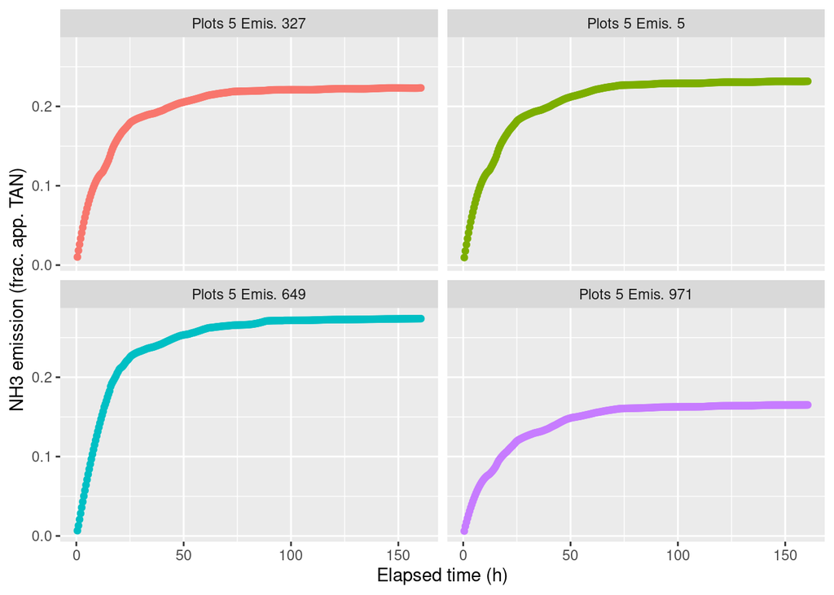

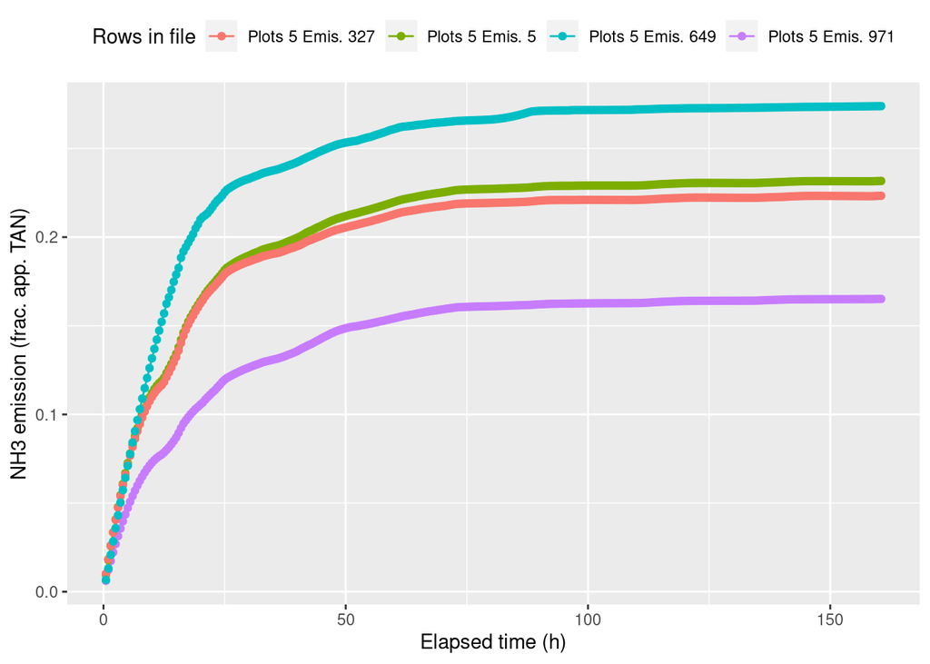

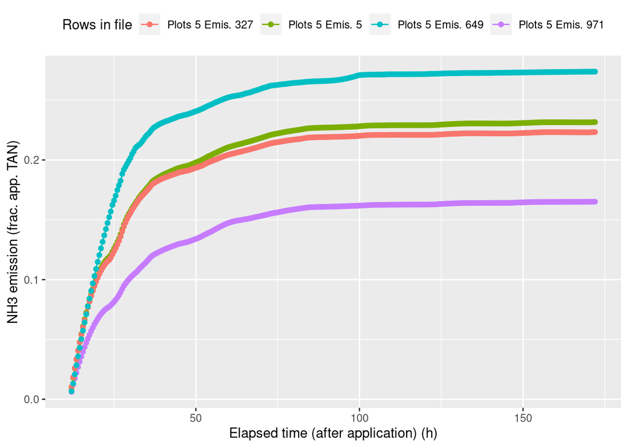

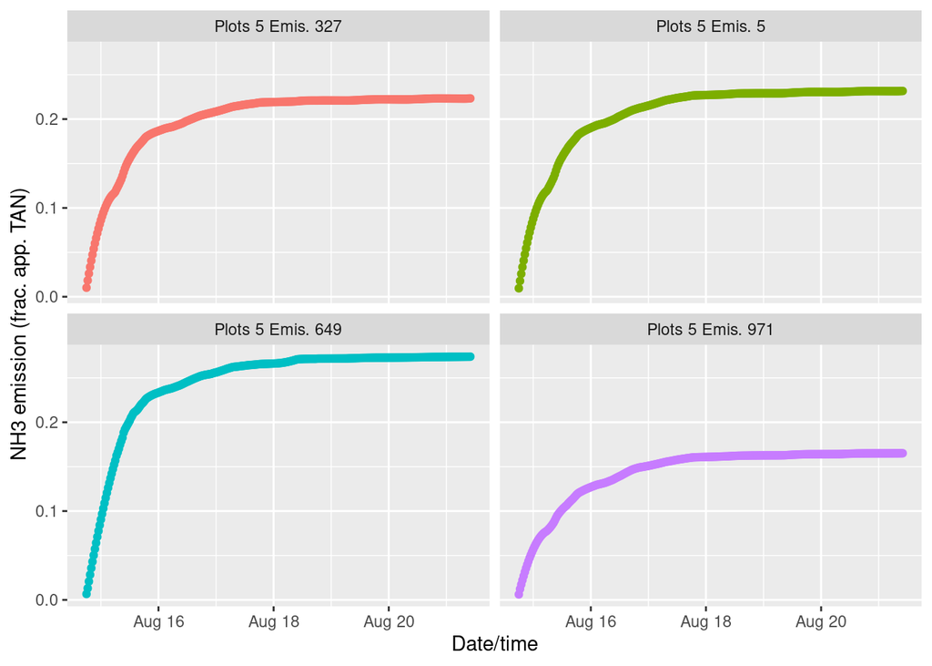

## Final cumulative emission

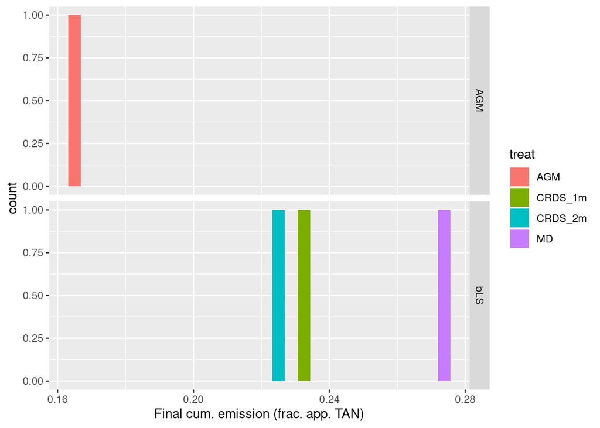

## Relative versus absolute emission

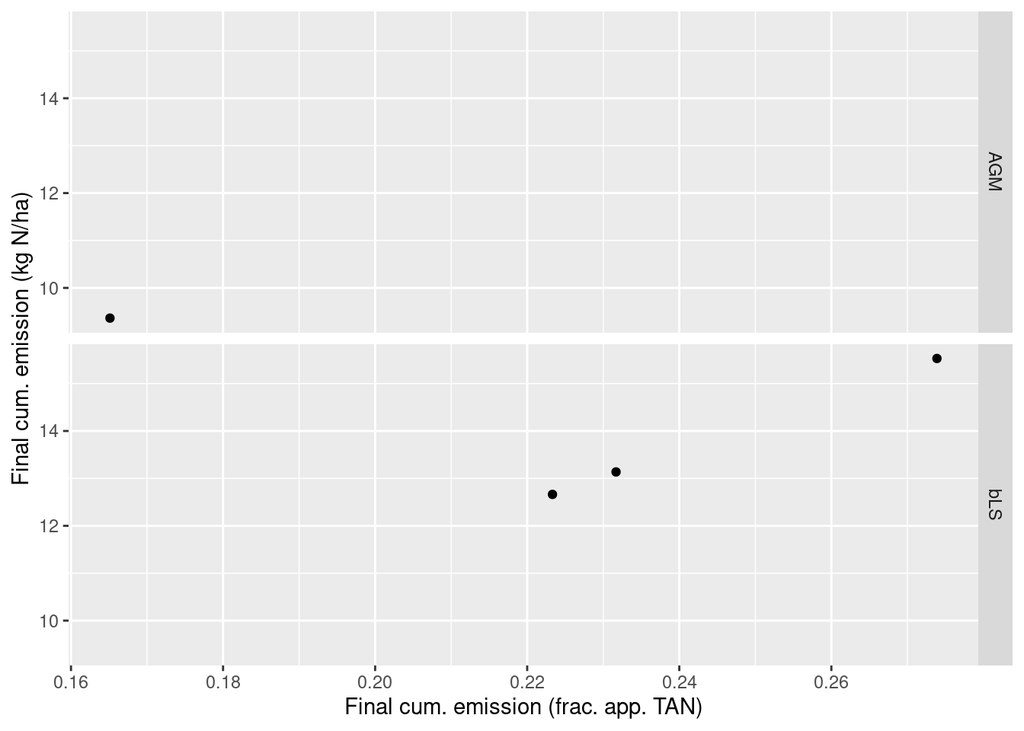

## Flux

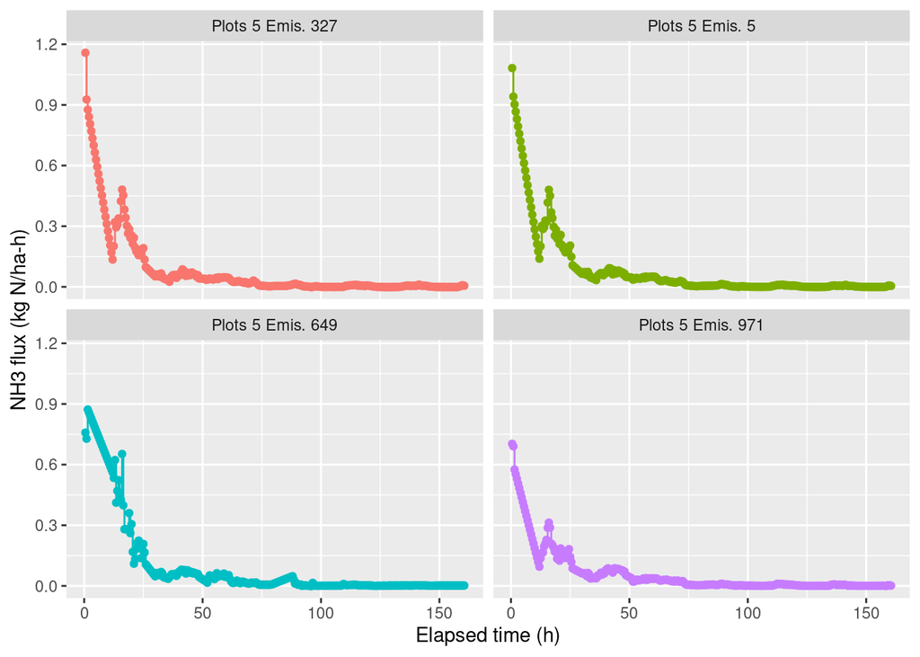

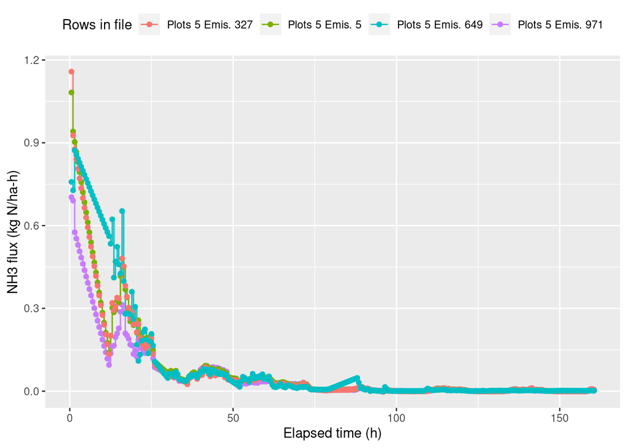

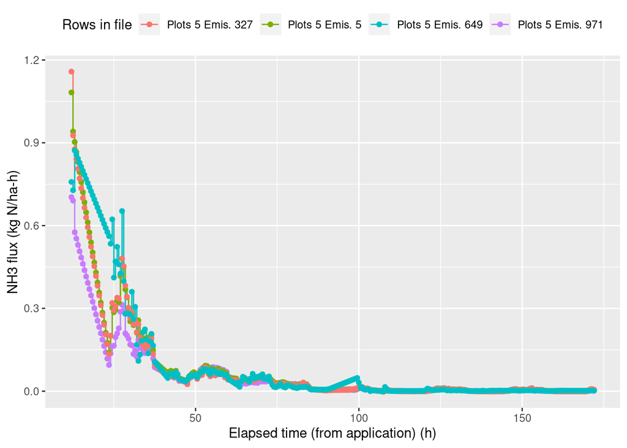

## Weather data

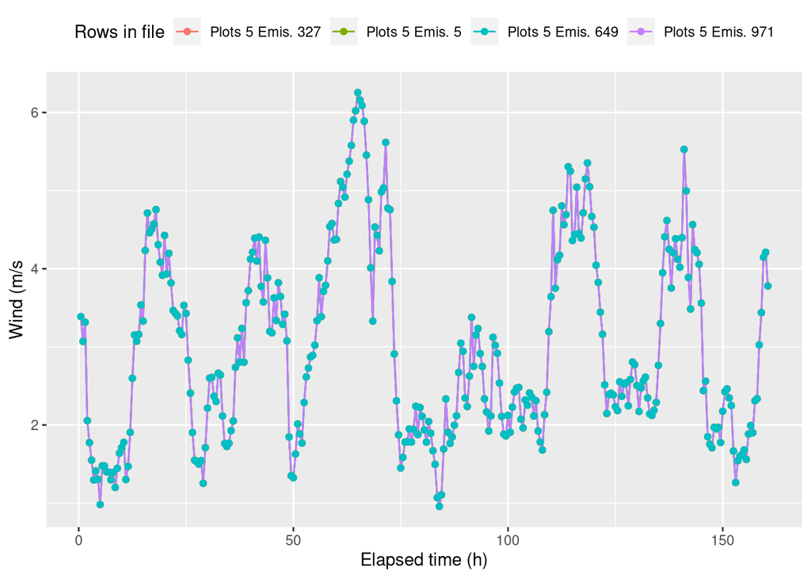

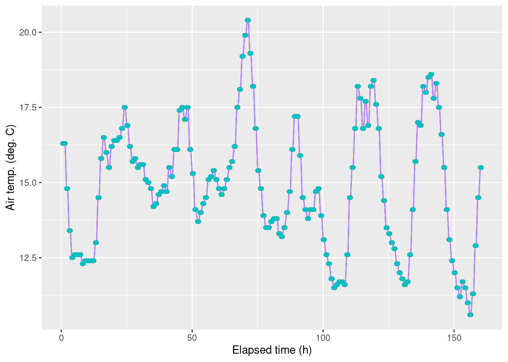

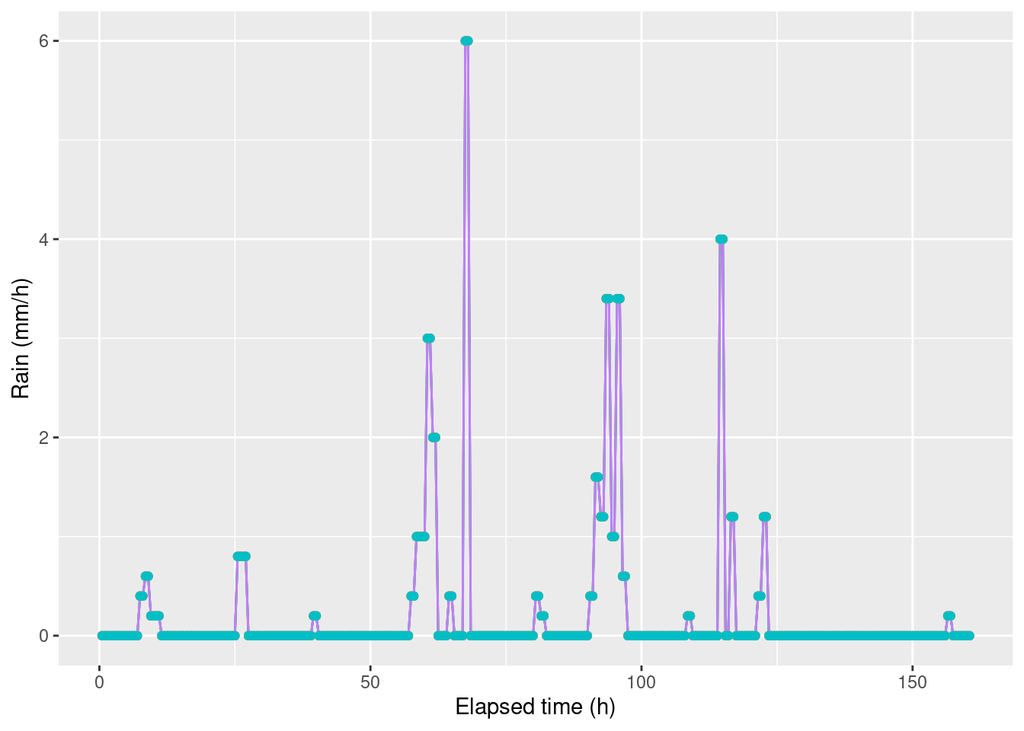

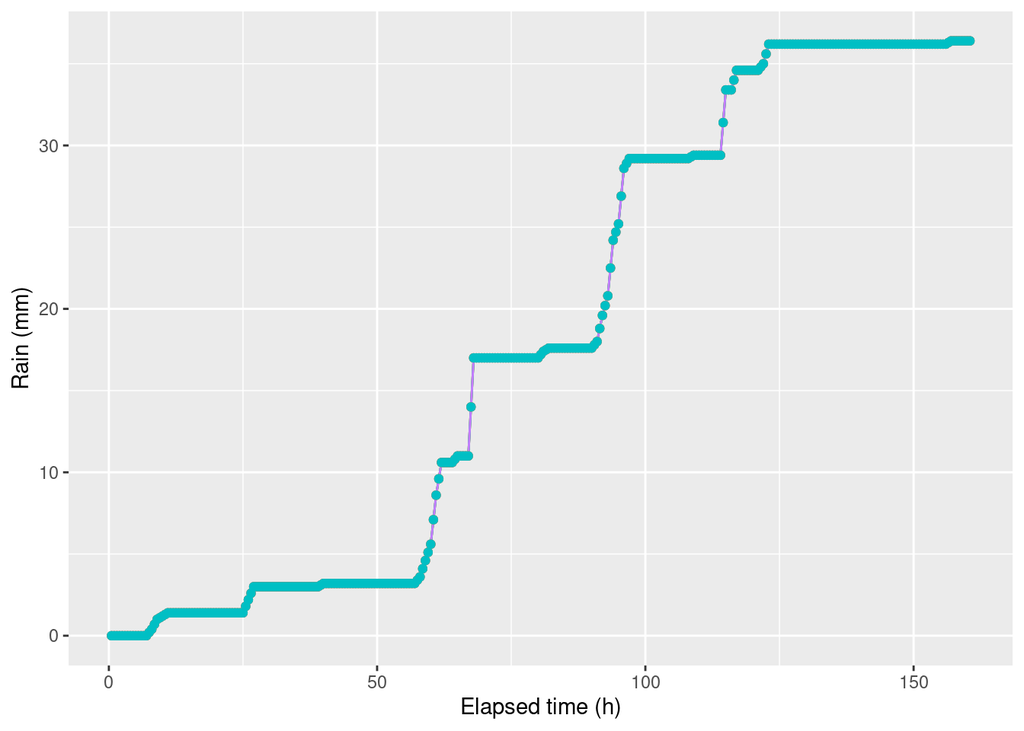

## Manure and application

| institute | proj | exper | field | plot | man.dm | man.ph | man.tan | app.rate | tan.app |
| --- | --- | --- | --- | --- | --- | --- | --- | --- | --- |
| AU | Vejrumbro_2019 | Vejrumbro_2019_Aug |  | 1 | 3.31 | 7.7 | 1.62 | 35 | 56.7 |
| AU | Vejrumbro_2019 | Vejrumbro_2019_Aug |  | 1 | 3.31 | 7.7 | 1.62 | 35 | 56.7 |
| AU | Vejrumbro_2019 | Vejrumbro_2019_Aug |  | 1 | 3.31 | 7.7 | 1.62 | 35 | 56.7 |
| AU | Vejrumbro_2019 | Vejrumbro_2019_Aug |  | 1 | 3.31 | 7.7 | 1.62 | 35 | 56.7 |

# 10. `dfsumm` summary

[output not shown]

[output cut: 524 more lines]

[output not shown]